# unsupervised learning

```python
import pandas as pd
import seaborn as sns
import numpy as np
import matplotlib.pyplot as plt
```

```python
car_df = pd.read_csv('Car name.csv')
car_att_df = pd.read_json('Car-Attributes.json')
```

```python
car_df
```

|  | car_name |
| --- | --- |
| 0 | chevrolet chevelle malibu |
| 1 | buick skylark 320 |
| 2 | plymouth satellite |
| 3 | amc rebel sst |
| 4 | ford torino |
| ... | ... |
| 393 | ford mustang gl |
| 394 | vw pickup |
| 395 | dodge rampage |
| 396 | ford ranger |
| 397 | chevy s-10 |

398 rows × 1 columns

```python
car_att_df
```

|  | mpg | cyl | disp | hp | wt | acc | yr | origin |
| --- | --- | --- | --- | --- | --- | --- | --- | --- |
| 0 | 18.0 | 8 | 307.0 | 130 | 3504 | 12.0 | 70 | 1 |
| 1 | 15.0 | 8 | 350.0 | 165 | 3693 | 11.5 | 70 | 1 |
| 2 | 18.0 | 8 | 318.0 | 150 | 3436 | 11.0 | 70 | 1 |
| 3 | 16.0 | 8 | 304.0 | 150 | 3433 | 12.0 | 70 | 1 |
| 4 | 17.0 | 8 | 302.0 | 140 | 3449 | 10.5 | 70 | 1 |
| ... | ... | ... | ... | ... | ... | ... | ... | ... |
| 393 | 27.0 | 4 | 140.0 | 86 | 2790 | 15.6 | 82 | 1 |
| 394 | 44.0 | 4 | 97.0 | 52 | 2130 | 24.6 | 82 | 2 |
| 395 | 32.0 | 4 | 135.0 | 84 | 2295 | 11.6 | 82 | 1 |
| 396 | 28.0 | 4 | 120.0 | 79 | 2625 | 18.6 | 82 | 1 |
| 397 | 31.0 | 4 | 119.0 | 82 | 2720 | 19.4 | 82 | 1 |

398 rows × 8 columns

```python
merged_df = pd.concat([car_att_df, car_df], axis = 1)
```

```python
merged_df.head(5)
```

|  | mpg | cyl | disp | hp | wt | acc | yr | origin | car_name |
| --- | --- | --- | --- | --- | --- | --- | --- | --- | --- |
| 0 | 18.0 | 8 | 307.0 | 130 | 3504 | 12.0 | 70 | 1 | chevrolet chevelle malibu |
| 1 | 15.0 | 8 | 350.0 | 165 | 3693 | 11.5 | 70 | 1 | buick skylark 320 |
| 2 | 18.0 | 8 | 318.0 | 150 | 3436 | 11.0 | 70 | 1 | plymouth satellite |
| 3 | 16.0 | 8 | 304.0 | 150 | 3433 | 12.0 | 70 | 1 | amc rebel sst |
| 4 | 17.0 | 8 | 302.0 | 140 | 3449 | 10.5 | 70 | 1 | ford torino |

```python
merged_df.describe()
```

|  | mpg | cyl | disp | wt | acc | yr | origin |
| --- | --- | --- | --- | --- | --- | --- | --- |
| count | 398.000000 | 398.000000 | 398.000000 | 398.000000 | 398.000000 | 398.000000 | 398.000000 |
| mean | 23.514573 | 5.454774 | 193.425879 | 2970.424623 | 15.568090 | 76.010050 | 1.572864 |
| std | 7.815984 | 1.701004 | 104.269838 | 846.841774 | 2.757689 | 3.697627 | 0.802055 |
| min | 9.000000 | 3.000000 | 68.000000 | 1613.000000 | 8.000000 | 70.000000 | 1.000000 |
| 25% | 17.500000 | 4.000000 | 104.250000 | 2223.750000 | 13.825000 | 73.000000 | 1.000000 |
| 50% | 23.000000 | 4.000000 | 148.500000 | 2803.500000 | 15.500000 | 76.000000 | 1.000000 |
| 75% | 29.000000 | 8.000000 | 262.000000 | 3608.000000 | 17.175000 | 79.000000 | 2.000000 |
| max | 46.600000 | 8.000000 | 455.000000 | 5140.000000 | 24.800000 | 82.000000 | 3.000000 |

```python
len(merged_df['car_name'].unique())
```

```
305
```

- MPG, which is miles per gallon has mean value of 23.5 and the max miles a car go on a gallon is 46 miles where as some car has gone minimun of 9 miles too.
- The maximum number of cylinders a car have is 8 and minimum is 3
- Displacement (is the combined volume of air moved — or displaced — by the pistons in its cylinders) it has a max value of 455 and min value of 68 . with mean as 193
- Weight, The avg weight of all car is 2970. The heaviest car weighed around 5140
- Acceleration has a max value of 24.8s and min value of 8s to reach 60 miles per hour

```python
merged_df.isnull().mean() * 100
```

```
mpg         0.0
cyl         0.0
disp        0.0
hp          0.0
wt          0.0
acc         0.0
yr          0.0
origin      0.0
car_name    0.0
dtype: float64
```

```python
# Check for missing values
print(merged_df.isnull().sum())
```

```
mpg         0
cyl         0
disp        0
hp          0
wt          0
acc         0
yr          0
origin      0
car_name    0
dtype: int64
```

There are no missing values, therefore we dont need to impute any values in this df

```python
print("duplicate rows count:", merged_df.duplicated().sum())
# There are no duplicate rows also in the dataframe.
```

```
duplicate rows count: 0
```

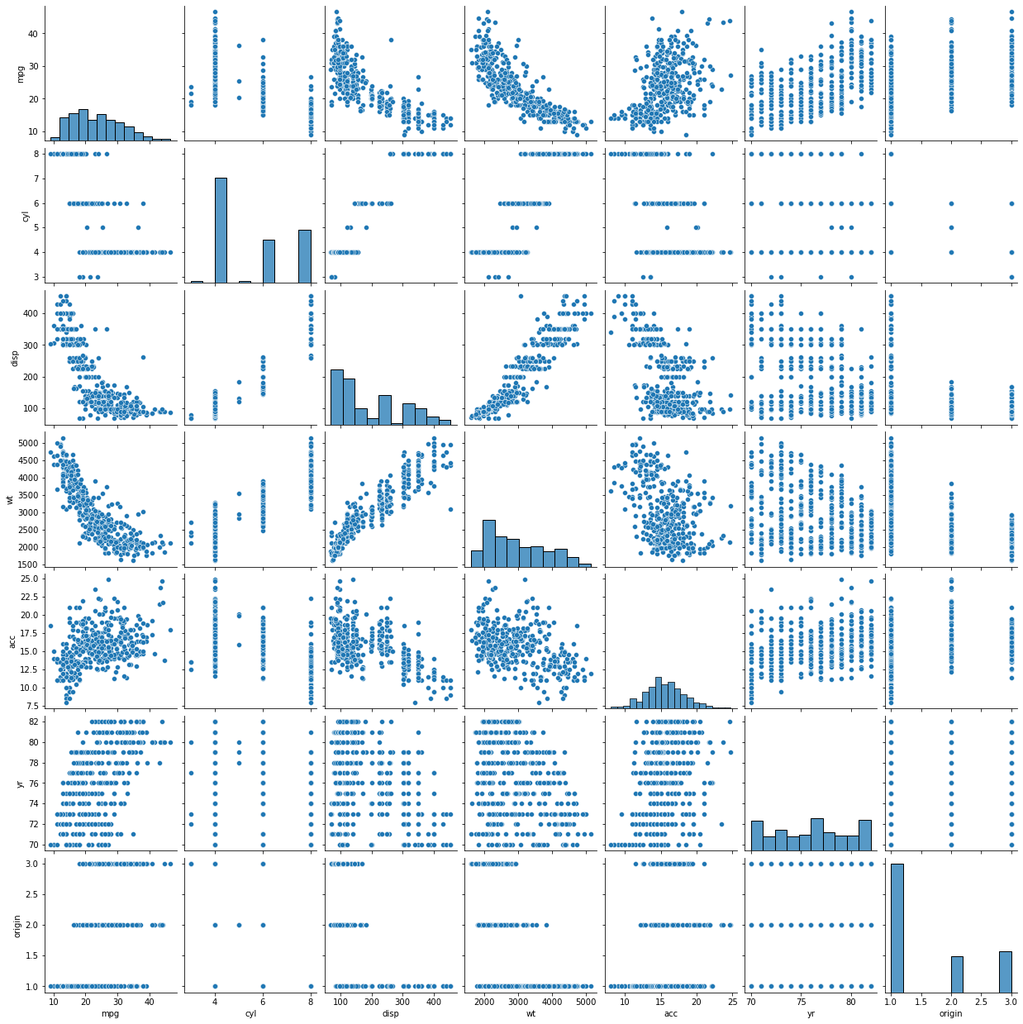

```python
sns.pairplot(merged_df)
```

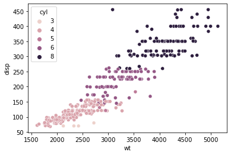

```python
sns.scatterplot(x = 'wt', y = 'disp', hue = 'cyl', data = merged_df)
```

- As the weight of the vehicle increases the displacement of the car also increases. The no of cylinders in the car increases with weight and displacement.

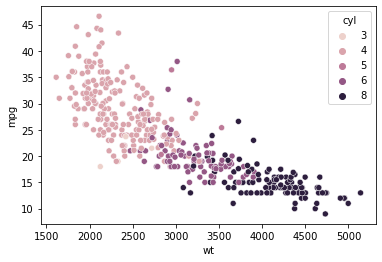

```python
sns.scatterplot(x = 'wt', y = 'mpg', hue = 'cyl', data = merged_df)
```

- Its also evident that as the weight increases the miles per gallon the car can go also decreases. And if the car has lower of cylinders it has more mileage.

```python
for i in merged_df.columns:
    print(i)
    print(merged_df[i].unique())
    print('\n')
```

```
mpg
[18.  15.  16.  17.  14.  24.  22.  21.  27.  26.  25.  10.  11.   9.
 28.  19.  12.  13.  23.  30.  31.  35.  20.  29.  32.  33.  17.5 15.5
 14.5 22.5 24.5 18.5 29.5 26.5 16.5 31.5 36.  25.5 33.5 20.5 30.5 21.5
 43.1 36.1 32.8 39.4 19.9 19.4 20.2 19.2 25.1 20.6 20.8 18.6 18.1 17.7
 27.5 27.2 30.9 21.1 23.2 23.8 23.9 20.3 21.6 16.2 19.8 22.3 17.6 18.2
 16.9 31.9 34.1 35.7 27.4 25.4 34.2 34.5 31.8 37.3 28.4 28.8 26.8 41.5
 38.1 32.1 37.2 26.4 24.3 19.1 34.3 29.8 31.3 37.  32.2 46.6 27.9 40.8
 44.3 43.4 36.4 44.6 40.9 33.8 32.7 23.7 23.6 32.4 26.6 25.8 23.5 39.1
 39.  35.1 32.3 37.7 34.7 34.4 29.9 33.7 32.9 31.6 28.1 30.7 24.2 22.4
 34.  38.  44. ]


cyl
[8 4 6 3 5]


disp
[307.  350.  318.  304.  302.  429.  454.  440.  455.  390.  383.  340.
 400.  113.  198.  199.  200.   97.  110.  107.  104.  121.  360.  140.
  98.  232.  225.  250.  351.  258.  122.  116.   79.   88.   71.   72.
  91.   97.5  70.  120.   96.  108.  155.   68.  114.  156.   76.   83.
  90.  231.  262.  134.  119.  171.  115.  101.  305.   85.  130.  168.
 111.  260.  151.  146.   80.   78.  105.  131.  163.   89.  267.   86.
 183.  141.  173.  135.   81.  100.  145.  112.  181.  144. ]


hp
[130 165 150 140 198 220 215 225 190 170 160 95 97 85 88 46 87 90 113 200
 210 193 '?' 100 105 175 153 180 110 72 86 70 76 65 69 60 80 54 208 155
 112 92 145 137 158 167 94 107 230 49 75 91 122 67 83 78 52 61 93 148 129
 96 71 98 115 53 81 79 120 152 102 108 68 58 149 89 63 48 66 139 103 125
 133 138 135 142 77 62 132 84 64 74 116 82]


wt
[3504 3693 3436 3433 3449 4341 4354 4312 4425 3850 3563 3609 3761 3086
 2372 2833 2774 2587 2130 1835 2672 2430 2375 2234 2648 4615 4376 4382
 4732 2264 2228 2046 2634 3439 3329 3302 3288 4209 4464 4154 4096 4955
 4746 5140 2962 2408 3282 3139 2220 2123 2074 2065 1773 1613 1834 1955
```

[output cut: 122 more lines]

```
 'plymouth reliant' 'dodge aries wagon (sw)' 'toyota starlet'
 'plymouth champ' 'honda civic 1300' 'datsun 210 mpg' 'toyota tercel'
 'mazda glc 4' 'plymouth horizon 4' 'ford escort 4w' 'ford escort 2h'
 'volkswagen jetta' 'renault 18i' 'honda prelude' 'datsun 200sx'
 'peugeot 505s turbo diesel' 'volvo diesel' 'toyota cressida'
 'datsun 810 maxima' 'oldsmobile cutlass ls' 'ford granada gl'
 'chrysler lebaron salon' 'chevrolet cavalier' 'chevrolet cavalier wagon'
 'chevrolet cavalier 2-door' 'pontiac j2000 se hatchback' 'dodge aries se'
 'ford fairmont futura' 'amc concord dl' 'volkswagen rabbit l'
 'mazda glc custom l' 'mazda glc custom' 'plymouth horizon miser'
 'mercury lynx l' 'nissan stanza xe' 'honda civic (auto)' 'datsun 310 gx'
 'buick century limited' 'oldsmobile cutlass ciera (diesel)'
 'chrysler lebaron medallion' 'ford granada l' 'toyota celica gt'
 'dodge charger 2.2' 'chevrolet camaro' 'ford mustang gl' 'vw pickup'
 'dodge rampage' 'ford ranger' 'chevy s-10']
```

- In hp column we have a have '?' , we need to impute this with an mean value

```python
merged_df.dtypes
```

```
mpg         float64
cyl           int64
disp        float64
hp           object
wt            int64
acc         float64
yr            int64
origin        int64
car_name     object
dtype: object
```

```python
merged_df['hp'] = merged_df['hp'].replace('?', np.nan)
merged_df['hp'] = merged_df['hp'].astype(float)
```

```python
merged_df['hp'].fillna(merged_df['hp'].mean(), inplace = True)
```

```python
merged_df['hp'].unique()
```

```
array([130.        , 165.        , 150.        , 140.        ,
       198.        , 220.        , 215.        , 225.        ,
       190.        , 170.        , 160.        ,  95.        ,
        97.        ,  85.        ,  88.        ,  46.        ,
        87.        ,  90.        , 113.        , 200.        ,
       210.        , 193.        , 104.46938776, 100.        ,
       105.        , 175.        , 153.        , 180.        ,
       110.        ,  72.        ,  86.        ,  70.        ,
        76.        ,  65.        ,  69.        ,  60.        ,
        80.        ,  54.        , 208.        , 155.        ,
       112.        ,  92.        , 145.        , 137.        ,
       158.        , 167.        ,  94.        , 107.        ,
       230.        ,  49.        ,  75.        ,  91.        ,
       122.        ,  67.        ,  83.        ,  78.        ,
        52.        ,  61.        ,  93.        , 148.        ,
       129.        ,  96.        ,  71.        ,  98.        ,
       115.        ,  53.        ,  81.        ,  79.        ,
       120.        , 152.        , 102.        , 108.        ,
        68.        ,  58.        , 149.        ,  89.        ,
        63.        ,  48.        ,  66.        , 139.        ,
       103.        , 125.        , 133.        , 138.        ,
       135.        , 142.        ,  77.        ,  62.        ,
       132.        ,  84.        ,  64.        ,  74.        ,
       116.        ,  82.        ])
```

```python
from sklearn.cluster import KMeans
inertia_values_df = []
```

```python
X = merged_df[['mpg', 'cyl', 'disp', 'hp', 'wt', 'acc']]
print(X)
```

```
      mpg  cyl   disp     hp    wt   acc
0    18.0    8  307.0  130.0  3504  12.0
1    15.0    8  350.0  165.0  3693  11.5
2    18.0    8  318.0  150.0  3436  11.0
3    16.0    8  304.0  150.0  3433  12.0
4    17.0    8  302.0  140.0  3449  10.5
..    ...  ...    ...    ...   ...   ...
393  27.0    4  140.0   86.0  2790  15.6
394  44.0    4   97.0   52.0  2130  24.6
395  32.0    4  135.0   84.0  2295  11.6
396  28.0    4  120.0   79.0  2625  18.6
397  31.0    4  119.0   82.0  2720  19.4

[398 rows x 6 columns]
```

```python
for k in range(2,11):
    kmeans = KMeans(n_clusters = k)
    kmeans.fit(X)
    inertia_values_df.append(kmeans.inertia_)
```

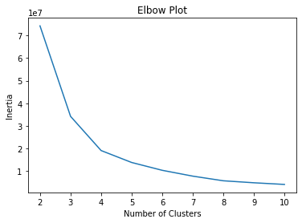

```python
plt.plot(range(2,11), inertia_values_df)
plt.xlabel('Number of Clusters')
plt.ylabel('Inertia')
plt.title('Elbow Plot')
plt.show()
```

- The possible elbow points are 4 and 3

```python
kmeans = KMeans(n_clusters = 4, random_state = 0)
kmeans.fit(X)
labels = kmeans.labels_
```

```python
merged_df['Cluster_value'] = labels
```

```python
merged_df
```

|  | mpg | cyl | disp | hp | wt | acc | yr | origin | car_name | Cluster_value |
| --- | --- | --- | --- | --- | --- | --- | --- | --- | --- | --- |
| 0 | 18.0 | 8 | 307.0 | 130.0 | 3504 | 12.0 | 70 | 1 | chevrolet chevelle malibu | 1 |
| 1 | 15.0 | 8 | 350.0 | 165.0 | 3693 | 11.5 | 70 | 1 | buick skylark 320 | 1 |
| 2 | 18.0 | 8 | 318.0 | 150.0 | 3436 | 11.0 | 70 | 1 | plymouth satellite | 1 |
| 3 | 16.0 | 8 | 304.0 | 150.0 | 3433 | 12.0 | 70 | 1 | amc rebel sst | 1 |
| 4 | 17.0 | 8 | 302.0 | 140.0 | 3449 | 10.5 | 70 | 1 | ford torino | 1 |
| ... | ... | ... | ... | ... | ... | ... | ... | ... | ... | ... |
| 393 | 27.0 | 4 | 140.0 | 86.0 | 2790 | 15.6 | 82 | 1 | ford mustang gl | 0 |
| 394 | 44.0 | 4 | 97.0 | 52.0 | 2130 | 24.6 | 82 | 2 | vw pickup | 3 |
| 395 | 32.0 | 4 | 135.0 | 84.0 | 2295 | 11.6 | 82 | 1 | dodge rampage | 3 |
| 396 | 28.0 | 4 | 120.0 | 79.0 | 2625 | 18.6 | 82 | 1 | ford ranger | 0 |
| 397 | 31.0 | 4 | 119.0 | 82.0 | 2720 | 19.4 | 82 | 1 | chevy s-10 | 0 |

398 rows × 10 columns

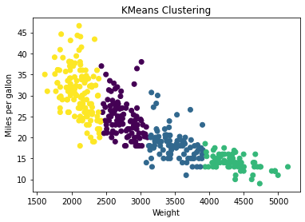

```python
plt.scatter(merged_df['wt'], merged_df['mpg'], c = merged_df['Cluster_value'], cmap = 'viridis')

plt.xlabel('Weight')
plt.ylabel('Miles per gallon')
plt.title('KMeans Clustering')

plt.show()
```

```python
# predicting cluster for new data point
```

```python
data = dict(mpg=30, cyl=6, disp=200, hp=80, wt=2255, acc=13)
df = pd.DataFrame(data, index=[0])
df
```

|  | mpg | cyl | disp | hp | wt | acc |
| --- | --- | --- | --- | --- | --- | --- |
| 0 | 30 | 6 | 200 | 80 | 2255 | 13 |

```python
new_data_point = np.array([30, 6, 200, 80, 2255, 13]).reshape(1, -1)
predicted_cluster = kmeans.predict(new_data_point)

print('Cluster label predicted :', predicted_cluster[0])
```

[output not shown]

# part 2

```python
vehicle_df = pd.read_csv('vehicle.csv')
```

```python
vehicle_df.head(5)
```

|  | compactness | circularity | distance_circularity | radius_ratio | pr.axis_aspect_ratio | max.length_aspect_ratio | scatter_ratio | elongatedness | pr.axis_rectangularity | max.length_rectangularity | scaled_variance | scaled_variance.1 | scaled_radius_of_gyration | scaled_radius_of_gyration.1 | skewness_about | skewness_about.1 | skewness_about.2 | hollows_ratio | class |
| --- | --- | --- | --- | --- | --- | --- | --- | --- | --- | --- | --- | --- | --- | --- | --- | --- | --- | --- | --- |
| 0 | 95 | 48.0 | 83.0 | 178.0 | 72.0 | 10 | 162.0 | 42.0 | 20.0 | 159 | 176.0 | 379.0 | 184.0 | 70.0 | 6.0 | 16.0 | 187.0 | 197 | van |
| 1 | 91 | 41.0 | 84.0 | 141.0 | 57.0 | 9 | 149.0 | 45.0 | 19.0 | 143 | 170.0 | 330.0 | 158.0 | 72.0 | 9.0 | 14.0 | 189.0 | 199 | van |
| 2 | 104 | 50.0 | 106.0 | 209.0 | 66.0 | 10 | 207.0 | 32.0 | 23.0 | 158 | 223.0 | 635.0 | 220.0 | 73.0 | 14.0 | 9.0 | 188.0 | 196 | car |
| 3 | 93 | 41.0 | 82.0 | 159.0 | 63.0 | 9 | 144.0 | 46.0 | 19.0 | 143 | 160.0 | 309.0 | 127.0 | 63.0 | 6.0 | 10.0 | 199.0 | 207 | van |
| 4 | 85 | 44.0 | 70.0 | 205.0 | 103.0 | 52 | 149.0 | 45.0 | 19.0 | 144 | 241.0 | 325.0 | 188.0 | 127.0 | 9.0 | 11.0 | 180.0 | 183 | bus |

```python
data_miss_pct = vehicle_df.isna().mean() * 100
data_miss_pct
```

```
compactness                    0.000000
circularity                    0.591017
distance_circularity           0.472813
radius_ratio                   0.709220
pr.axis_aspect_ratio           0.236407
max.length_aspect_ratio        0.000000
scatter_ratio                  0.118203
elongatedness                  0.118203
pr.axis_rectangularity         0.354610
max.length_rectangularity      0.000000
scaled_variance                0.354610
scaled_variance.1              0.236407
scaled_radius_of_gyration      0.236407
scaled_radius_of_gyration.1    0.472813
skewness_about                 0.709220
skewness_about.1               0.118203
skewness_about.2               0.118203
hollows_ratio                  0.000000
class                          0.000000
dtype: float64
```

```python
for i in vehicle_df.columns:
    print(i)
    print(vehicle_df[i].unique())
    print('\n')
```

```
compactness
[ 95  91 104  93  85 107  97  90  86  88  89  94  96  99 101  84  87  83
 102  80 100  82 106  81 119  78  92  98 103  77  73  79 110 108 109 111
 105 112 116 113 117 115  76 114]


circularity
[48. 41. 50. 44. nan 43. 34. 36. 46. 42. 49. 55. 54. 56. 47. 37. 39. 53.
 45. 38. 35. 40. 59. 52. 51. 58. 57. 33.]


distance_circularity
[ 83.  84. 106.  82.  70.  73.  66.  62.  98.  74.  85.  79. 103.  51.
  77. 100.  75.  53.  64. 105.  80.  54.  63. 107.  nan  72.  86.  68.
 104.  87.  76.  81.  71. 101.  96.  78. 108.  91.  89.  94.  92.  60.
  57.  65.  50.  88. 109.  95.  90.  58.  69.  47.  40.  59. 110.  93.
 102. 112.  61.  42.  49.  44.  52.  55.]


radius_ratio
[178. 141. 209. 159. 205. 172. 173. 157. 140.  nan 143. 136. 171. 144.
 203. 201. 109. 197. 186. 215. 153. 121. 148. 219. 154. 119. 193. 129.
 160. 151. 222. 177. 118. 306. 176. 169. 214. 105. 137. 183. 220. 145.
 133. 122. 147. 115. 174. 228. 175. 185. 195. 221. 212. 135. 120. 156.
 125. 164. 161. 227. 191. 111. 170. 113. 127. 188. 180. 116. 158. 162.
 211. 152. 124. 252. 150. 130. 198. 202. 199. 128. 142. 163. 155. 184.
 165. 322. 194. 218. 216. 223. 149. 131. 139. 179. 166. 187. 167. 231.
 168. 126. 206. 210. 110. 189. 134. 132. 230. 196. 208. 138. 200. 225.
 246. 207. 192. 117. 123. 146. 190. 182. 204. 224. 333. 213. 226. 238.
 181. 114. 104. 112. 234. 235. 250. 232. 217.]


pr.axis_aspect_ratio
[ 72.  57.  66.  63. 103.  50.  65.  61.  62.  55.  68.  58.  71.  52.
  69.  nan  64.  59.  67. 126.  54.  73.  51.  70.  53.  56.  74.  60.
  76.  75.  49. 133.  47. 102. 138.  48.  97. 105.]


max.length_aspect_ratio
[10  9 52  6  7 11  5  8 49 12 22 48  4 13  3 43 25 46 19  2 55]
```

[output cut: 112 more lines]

```


skewness_about.2
[187. 189. 188. 199. 180. 181. 200. 193. 195. 194. 196. 197. 186. 198.
 185. 179. 192. 191. 190. 183. 184. 202. 201. 182. 176. 178. 203. 177.
  nan 204. 206.]


hollows_ratio
[197 199 196 207 183 204 202 208 195 194 185 193 192 206 201 205 200 189
 182 209 184 187 188 198 191 190 203 186 210 211 181]


class
['van' 'car' 'bus']
```

```python
vehicle_df.fillna(vehicle_df.mean(), inplace=True)
```

```python
for i in vehicle_df.columns:
    print(i)
    print(vehicle_df[i].unique())
    print('\n')
```

```
compactness
[ 95  91 104  93  85 107  97  90  86  88  89  94  96  99 101  84  87  83
 102  80 100  82 106  81 119  78  92  98 103  77  73  79 110 108 109 111
 105 112 116 113 117 115  76 114]


circularity
[48.         41.         50.         44.         44.82877527 43.
 34.         36.         46.         42.         49.         55.
 54.         56.         47.         37.         39.         53.
 45.         38.         35.         40.         59.         52.
 51.         58.         57.         33.        ]


distance_circularity
[ 83.          84.         106.          82.          70.
  73.          66.          62.          98.          74.
  85.          79.         103.          51.          77.
 100.          75.          53.          64.         105.
  80.          54.          63.         107.          82.11045131
  72.          86.          68.         104.          87.
  76.          81.          71.         101.          96.
  78.         108.          91.          89.          94.
  92.          60.          57.          65.          50.
  88.         109.          95.          90.          58.
  69.          47.          40.          59.         110.
  93.         102.         112.          61.          42.
  49.          44.          52.          55.        ]


radius_ratio
[178.         141.         209.         159.         205.
 172.         173.         157.         140.         168.88809524
 143.         136.         171.         144.         203.
 201.         109.         197.         186.         215.
 153.         121.         148.         219.         154.
 119.         193.         129.         160.         151.
 222.         177.         118.         306.         176.
 169.         214.         105.         137.         183.
 220.         145.         133.         122.         147.
```

[output cut: 266 more lines]

```
 181.         200.         193.         195.         194.
 196.         197.         186.         198.         185.
 179.         192.         191.         190.         183.
 184.         202.         201.         182.         176.
 178.         203.         177.         188.91952663 204.
 206.        ]


hollows_ratio
[197 199 196 207 183 204 202 208 195 194 185 193 192 206 201 205 200 189
 182 209 184 187 188 198 191 190 203 186 210 211 181]


class
['van' 'car' 'bus']
```

```python
class_count = vehicle_df['class'].value_counts()
class_count
```

```
car    429
bus    218
van    199
Name: class, dtype: int64
```

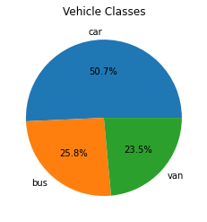

```python
class_count.plot.pie(autopct='%1.1f%%')
plt.title('Vehicle Classes')
plt.ylabel('')
plt.show()
```

```python
duplicate_data = vehicle_df.duplicated()
print('Number of duplicates:', duplicate_data.sum())
```

```
Number of duplicates: 0
```

- There are no duplicate values in the dataframe

```python
vehicle_df.dtypes
```

```
compactness                      int64
circularity                    float64
distance_circularity           float64
radius_ratio                   float64
pr.axis_aspect_ratio           float64
max.length_aspect_ratio          int64
scatter_ratio                  float64
elongatedness                  float64
pr.axis_rectangularity         float64
max.length_rectangularity        int64
scaled_variance                float64
scaled_variance.1              float64
scaled_radius_of_gyration      float64
scaled_radius_of_gyration.1    float64
skewness_about                 float64
skewness_about.1               float64
skewness_about.2               float64
hollows_ratio                    int64
class                           object
dtype: object
```

```python
X = vehicle_df.drop('class', axis=1)
Y = vehicle_df['class']
```

```python
X
```

|  | compactness | circularity | distance_circularity | radius_ratio | pr.axis_aspect_ratio | max.length_aspect_ratio | scatter_ratio | elongatedness | pr.axis_rectangularity | max.length_rectangularity | scaled_variance | scaled_variance.1 | scaled_radius_of_gyration | scaled_radius_of_gyration.1 | skewness_about | skewness_about.1 | skewness_about.2 | hollows_ratio |
| --- | --- | --- | --- | --- | --- | --- | --- | --- | --- | --- | --- | --- | --- | --- | --- | --- | --- | --- |
| 0 | 95 | 48.0 | 83.0 | 178.0 | 72.0 | 10 | 162.0 | 42.0 | 20.0 | 159 | 176.0 | 379.0 | 184.0 | 70.0 | 6.0 | 16.0 | 187.0 | 197 |
| 1 | 91 | 41.0 | 84.0 | 141.0 | 57.0 | 9 | 149.0 | 45.0 | 19.0 | 143 | 170.0 | 330.0 | 158.0 | 72.0 | 9.0 | 14.0 | 189.0 | 199 |
| 2 | 104 | 50.0 | 106.0 | 209.0 | 66.0 | 10 | 207.0 | 32.0 | 23.0 | 158 | 223.0 | 635.0 | 220.0 | 73.0 | 14.0 | 9.0 | 188.0 | 196 |
| 3 | 93 | 41.0 | 82.0 | 159.0 | 63.0 | 9 | 144.0 | 46.0 | 19.0 | 143 | 160.0 | 309.0 | 127.0 | 63.0 | 6.0 | 10.0 | 199.0 | 207 |
| 4 | 85 | 44.0 | 70.0 | 205.0 | 103.0 | 52 | 149.0 | 45.0 | 19.0 | 144 | 241.0 | 325.0 | 188.0 | 127.0 | 9.0 | 11.0 | 180.0 | 183 |
| ... | ... | ... | ... | ... | ... | ... | ... | ... | ... | ... | ... | ... | ... | ... | ... | ... | ... | ... |
| 841 | 93 | 39.0 | 87.0 | 183.0 | 64.0 | 8 | 169.0 | 40.0 | 20.0 | 134 | 200.0 | 422.0 | 149.0 | 72.0 | 7.0 | 25.0 | 188.0 | 195 |
| 842 | 89 | 46.0 | 84.0 | 163.0 | 66.0 | 11 | 159.0 | 43.0 | 20.0 | 159 | 173.0 | 368.0 | 176.0 | 72.0 | 1.0 | 20.0 | 186.0 | 197 |
| 843 | 106 | 54.0 | 101.0 | 222.0 | 67.0 | 12 | 222.0 | 30.0 | 25.0 | 173 | 228.0 | 721.0 | 200.0 | 70.0 | 3.0 | 4.0 | 187.0 | 201 |
| 844 | 86 | 36.0 | 78.0 | 146.0 | 58.0 | 7 | 135.0 | 50.0 | 18.0 | 124 | 155.0 | 270.0 | 148.0 | 66.0 | 0.0 | 25.0 | 190.0 | 195 |
| 845 | 85 | 36.0 | 66.0 | 123.0 | 55.0 | 5 | 120.0 | 56.0 | 17.0 | 128 | 140.0 | 212.0 | 131.0 | 73.0 | 1.0 | 18.0 | 186.0 | 190 |

846 rows × 18 columns

```python
Y
```

```
0      van
1      van
2      car
3      van
4      bus
      ...
841    car
842    van
843    car
844    car
845    van
Name: class, Length: 846, dtype: object
```

```python
from sklearn.preprocessing import StandardScaler
```

```python
scaler = StandardScaler()
X_data = scaler.fit_transform(X)
```

```python
X_data
```

```
array([[ 0.16058035,  0.51730193,  0.05654535, ...,  0.38066534,
        -0.31219283,  0.18395733],
       [-0.32546965, -0.62456401,  0.12011169, ...,  0.15658856,
         0.01308823,  0.45297703],
       [ 1.25419283,  0.84354934,  1.51857115, ..., -0.40360337,
        -0.1495523 ,  0.04944748],
       ...,
       [ 1.49721783,  1.49604417,  1.20073946, ..., -0.96379531,
        -0.31219283,  0.72199673],
       [-0.93303214, -1.44018254, -0.26128634, ...,  1.38901082,
         0.17572877, -0.08506238],
       [-1.05454464, -1.44018254, -1.02408241, ...,  0.60474211,
        -0.47483337, -0.75761164]])
```

```python
from sklearn.model_selection import train_test_split
from sklearn.svm import SVC
from sklearn.metrics import accuracy_score
from sklearn.metrics import classification_report
```

```python
X_train, X_test, y_train, y_test = train_test_split(X_data, Y, test_size=0.2, random_state=42)

# SVM model
svm = SVC(kernel='linear')
svm.fit(X_train, y_train)

# predictions on test data
y_pred = svm.predict(X_test)

# Evaluating model performance
accuracy = accuracy_score(y_test, y_pred)
print('Accuracy:', accuracy)
```

```
Accuracy: 0.9294117647058824
```

```python
from sklearn.decomposition import PCA

pca = PCA(n_components = 10)
X_pca = pca.fit_transform(X_data)
```

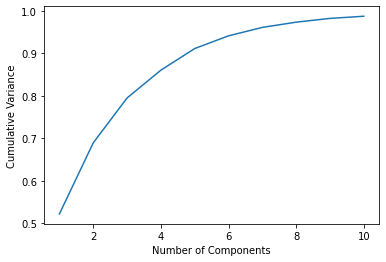

```python
import numpy as np
import matplotlib.pyplot as plt

cumulative_variance = np.cumsum(pca.explained_variance_ratio_)

plt.plot(range(1, 11), cumulative_variance)
plt.xlabel('Number of Components')
plt.ylabel('Cumulative Variance')
plt.show()
```

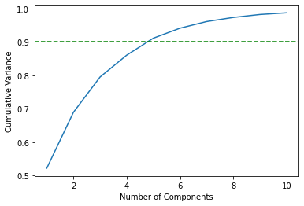

```python
plt.plot(range(1, 11), cumulative_variance)
plt.xlabel('Number of Components')
plt.ylabel('Cumulative Variance')
plt.axhline(y=0.9, color='g', linestyle='--')
plt.show()
```

```python
# Apply PCA to select minimum components with 90% variance explained
pca = PCA(n_components = 0.9)
X_pca = pca.fit_transform(X_data)
print(f"Number of components selected: {pca.n_components_}")
```

```
Number of components selected: 5
```

```python
X_train, X_test, y_train, y_test = train_test_split(X_pca, Y, test_size = 0.2, random_state = 0)

svm = SVC()
svm.fit(X_train, y_train)

y_train_pred = svm.predict(X_train)
print(classification_report(y_train, y_train_pred))
```

```
              precision    recall  f1-score   support

         bus       0.85      0.71      0.77       178
         car       0.84      0.87      0.86       334
         van       0.69      0.76      0.72       164

    accuracy                           0.80       676
   macro avg       0.79      0.78      0.78       676
weighted avg       0.81      0.80      0.80       676
```

```python
y_test_pred = svm.predict(X_test)
test_acc = accuracy_score(y_test, y_test_pred)
print("Test accuracy: ", test_acc)
print(classification_report(y_test, y_test_pred))
```

```
Test accuracy:  0.7941176470588235
              precision    recall  f1-score   support

         bus       0.78      0.70      0.74        40
         car       0.87      0.88      0.87        95
         van       0.62      0.66      0.64        35

    accuracy                           0.79       170
   macro avg       0.76      0.75      0.75       170
weighted avg       0.79      0.79      0.79       170
```

- Precision, Recall, F1-Score of the model for all classes is nearly 0.78 on training data and in testing data its around 0.75. Even though there is slight underfitting the model is okay to work with.
- To increase model effciiency we do hyperparameter tuning with Gridsearch or Randomsearch

```python
from sklearn.model_selection import GridSearchCV

param_grid = {'C': [0.1, 1, 10], 'kernel': ['linear', 'rbf', 'poly'], 'gamma': ['scale', 'auto']}
svm = SVC()

grid_search = GridSearchCV(estimator = svm, param_grid = param_grid, cv = 5)

grid_search.fit(X_train, y_train)

print(f"Best Parameters: {grid_search.best_params_}")
print(f"Best Score: {grid_search.best_score_}")
```

```
Best Parameters: {'C': 10, 'gamma': 'scale', 'kernel': 'rbf'}
Best Score: 0.8032897603485839
```

```python
# Train model with best hyperparameters
svm = SVC(C = 10, kernel = 'rbf', gamma = 'scale')
svm.fit(X_train, y_train)

# Print classification metrics for train data
y_train_pred = svm.predict(X_train)
print(classification_report(y_train, y_train_pred))
```

```
              precision    recall  f1-score   support

         bus       0.86      0.81      0.83       178
         car       0.90      0.91      0.91       334
         van       0.79      0.82      0.80       164

    accuracy                           0.86       676
   macro avg       0.85      0.85      0.85       676
weighted avg       0.86      0.86      0.86       676
```

```python
y_test_pred = svm.predict(X_test)
test_acc = accuracy_score(y_test, y_test_pred)
print("Test accuracy: ", test_acc)
print(classification_report(y_test, y_test_pred))
```

```
Test accuracy:  0.8235294117647058
              precision    recall  f1-score   support

         bus       0.81      0.75      0.78        40
         car       0.88      0.89      0.89        95
         van       0.69      0.71      0.70        35

    accuracy                           0.82       170
   macro avg       0.79      0.79      0.79       170
weighted avg       0.82      0.82      0.82       170
```

Pre-requisite of PCA:

- It assumes the relationship between variables in the dataset is linear
- We need to scale data before using PCA as its sensitive to this
- PCA works better if there is more variance in the data

Advantages of PCA :

- It helps to reduce dimentionality of the data
- Helps to extract important features
- Noise Reduction

Disadvantages of PCA:

- Its not easy to understand the principal components every time
- Information loss